# Credit Card Customer Segmentation

Submitted By: Mayur Makadia

**Github: https://github.com/mayurmakadia1/UTAustin-PGP-AIML/tree/master/3-Unsupervised-Learning/**

# Objective:

To identify different segments in the existing customer based on their spending patterns as well as past interaction with the bank.

# Background:

AllLife Bank wants to focus on its credit card customer base in the next financial year. They have been advised by their marketing research team, that the penetration in the market can be improved. Based on this input, the Marketing team proposes to run personalised campaigns to target new customers as well as upsell to existing customers. Another insight from the market research was that the customers perceive the support services of the back poorly. Based on this, the Operations team wants to upgrade the service delivery model, to ensure that customers queries are resolved faster. Head of Marketing and Head of Delivery both decide to reach out to the Data Science team for help.

# Data Description:

Data is of various customers of a bank with their credit limit, the total number of credit cards the customer has, and different channels through which customer has contacted the bank for any queries, different channels include visiting the bank, online and through a call.

- Customer key - Identifier for the customer
- Average Credit Limit - Average credit limit across all the credit cards
- Total credit cards - Total number of credit cards
- Total visits bank - Total number of bank visits
- Total visits online - total number of online visits
- Total calls made - Total number of calls made by the customer

# Key Questions:

- How many different segments of customers are there?
- How are these segments different from each other?
- What are your recommendations to the bank on how to better market to and service these customers?

```python
# To enable plotting graphs in Jupyter notebook
%matplotlib inline
```

```python
# Numerical libraries
import numpy as np

from sklearn.model_selection import train_test_split

from sklearn.cluster import KMeans

# to handle data in form of rows and columns
import pandas as pd

# importing ploting libraries
import matplotlib.pyplot as plt

#importing seaborn for statistical plots
import seaborn as sns

from sklearn import metrics

import pandas as pd
```

```python
# reading the CSV file into pandas dataframe
mydata = pd.read_excel("Credit Card Customer Data.xlsx")
```

# EDA

```python
mydata.head()
```

|  | Sl_No | Customer Key | Avg_Credit_Limit | Total_Credit_Cards | Total_visits_bank | Total_visits_online | Total_calls_made |
| --- | --- | --- | --- | --- | --- | --- | --- |
| 0 | 1 | 87073 | 100000 | 2 | 1 | 1 | 0 |
| 1 | 2 | 38414 | 50000 | 3 | 0 | 10 | 9 |
| 2 | 3 | 17341 | 50000 | 7 | 1 | 3 | 4 |
| 3 | 4 | 40496 | 30000 | 5 | 1 | 1 | 4 |
| 4 | 5 | 47437 | 100000 | 6 | 0 | 12 | 3 |

```python
#check data types
mydata.dtypes
```

```
Sl_No                  int64
Customer Key           int64
Avg_Credit_Limit       int64
Total_Credit_Cards     int64
Total_visits_bank      int64
Total_visits_online    int64
Total_calls_made       int64
dtype: object
```

```python
# check the data frame - number or rows and columns
mydata.shape
```

```
(660, 7)
```

```python
#check for any null values
mydata.isnull().sum()
```

```
Sl_No                  0
Customer Key           0
Avg_Credit_Limit       0
Total_Credit_Cards     0
Total_visits_bank      0
Total_visits_online    0
Total_calls_made       0
dtype: int64
```

```python
# check for data frame info
mydata.info()
```

```
<class 'pandas.core.frame.DataFrame'>
RangeIndex: 660 entries, 0 to 659
Data columns (total 7 columns):
 #   Column               Non-Null Count  Dtype
---  ------               --------------  -----
 0   Sl_No                660 non-null    int64
 1   Customer Key         660 non-null    int64
 2   Avg_Credit_Limit     660 non-null    int64
 3   Total_Credit_Cards   660 non-null    int64
 4   Total_visits_bank    660 non-null    int64
 5   Total_visits_online  660 non-null    int64
 6   Total_calls_made     660 non-null    int64
dtypes: int64(7)
memory usage: 36.2 KB
```

```python
# check for data distribution and quartiles
mydata.describe().transpose()
```

|  | count | mean | std | min | 25% | 50% | 75% | max |
| --- | --- | --- | --- | --- | --- | --- | --- | --- |
| Sl_No | 660.0 | 330.500000 | 190.669872 | 1.0 | 165.75 | 330.5 | 495.25 | 660.0 |
| Customer Key | 660.0 | 55141.443939 | 25627.772200 | 11265.0 | 33825.25 | 53874.5 | 77202.50 | 99843.0 |
| Avg_Credit_Limit | 660.0 | 34574.242424 | 37625.487804 | 3000.0 | 10000.00 | 18000.0 | 48000.00 | 200000.0 |
| Total_Credit_Cards | 660.0 | 4.706061 | 2.167835 | 1.0 | 3.00 | 5.0 | 6.00 | 10.0 |
| Total_visits_bank | 660.0 | 2.403030 | 1.631813 | 0.0 | 1.00 | 2.0 | 4.00 | 5.0 |
| Total_visits_online | 660.0 | 2.606061 | 2.935724 | 0.0 | 1.00 | 2.0 | 4.00 | 15.0 |
| Total_calls_made | 660.0 | 3.583333 | 2.865317 | 0.0 | 1.00 | 3.0 | 5.00 | 10.0 |

```python
#check if there are any duplicate customer entries
dupl = mydata[mydata.duplicated('Customer Key')]
dupl = dupl['Customer Key']
dupl
```

```
332    47437
398    96929
432    37252
541    50706
632    97935
Name: Customer Key, dtype: int64
```

```python
# delete all duplicate customer entries
for row in dupl:
    print(row)
    indexName = mydata[ mydata['Customer Key'] == row].index
    mydata.drop(indexName , inplace=True)
```

```
47437
96929
37252
50706
97935
```

```python
mydata.shape
```

```
(650, 7)
```

```python
#check if any values negative - those values would be incorrect and will need to be treated
mydata[mydata < 0].count()
```

```
Sl_No                  0
Customer Key           0
Avg_Credit_Limit       0
Total_Credit_Cards     0
Total_visits_bank      0
Total_visits_online    0
Total_calls_made       0
dtype: int64
```

```python
##Remove Sl_No since it is redundant
mydata.drop('Sl_No', axis=1, inplace=True)
```

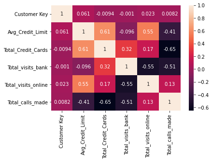

```python
corr = mydata.corr()
sns.heatmap(corr, annot = True)
```

```python
mydata.drop(columns = {'Customer Key'}, inplace=True)
```

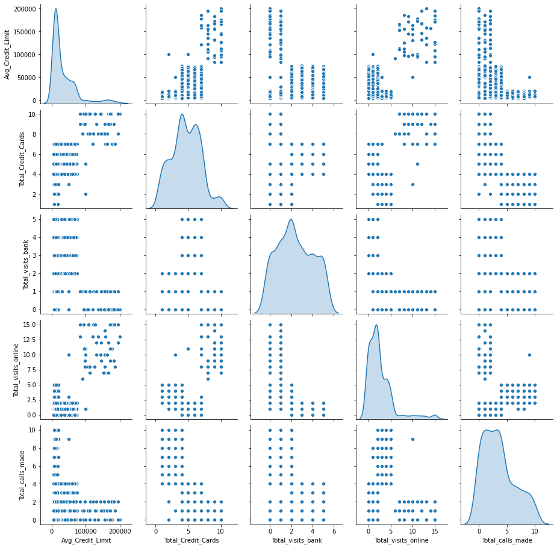

```python
import seaborn as sns
sns.pairplot(mydata, diag_kind='kde')
```

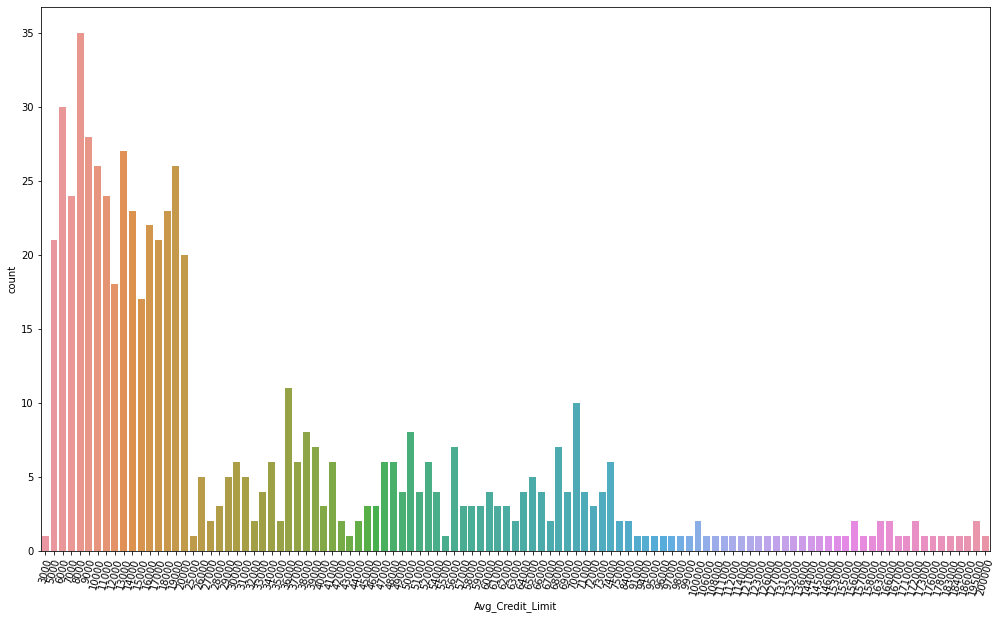

```python
plt.figure(figsize=(17,10))
sns.countplot(mydata['Avg_Credit_Limit'])
plt.xticks(rotation=75)
plt.show()
```

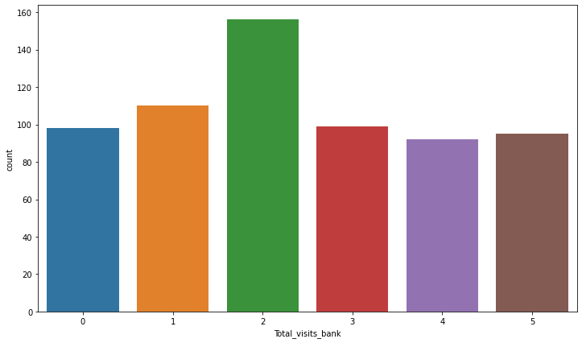

```python
plt.figure(figsize=(12,7))
sns.countplot(mydata['Total_visits_bank'])
#plt.xticks(rotation=90)
plt.show()
```

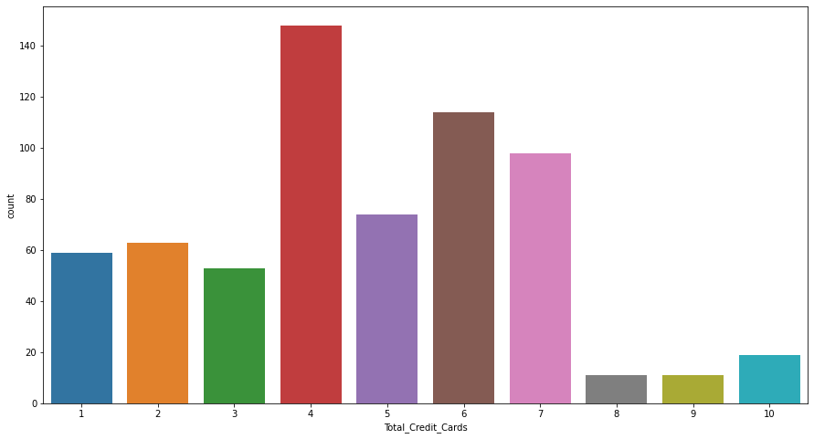

```python
plt.figure(figsize=(15,8))
sns.countplot(mydata['Total_Credit_Cards'])
#plt.xticks(rotation=90)
plt.show()
```

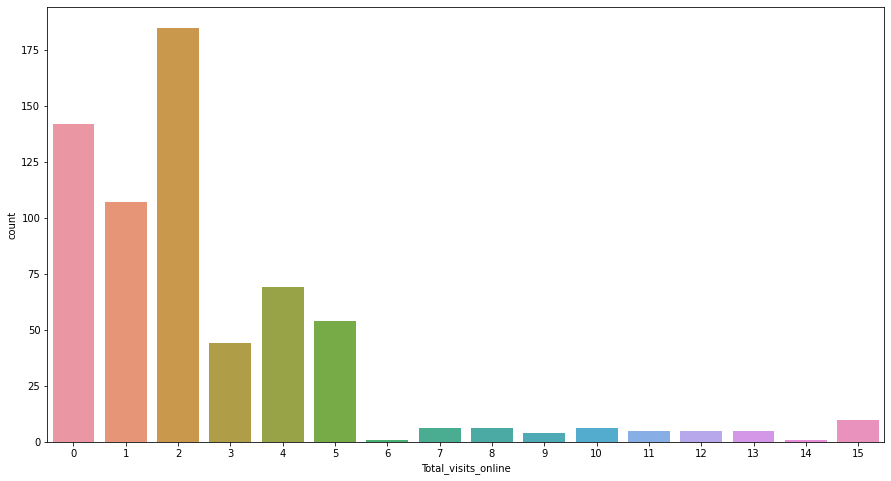

```python
plt.figure(figsize=(15,8))
sns.countplot(mydata['Total_visits_online'])
#plt.xticks(rotation=90)
plt.show()
```

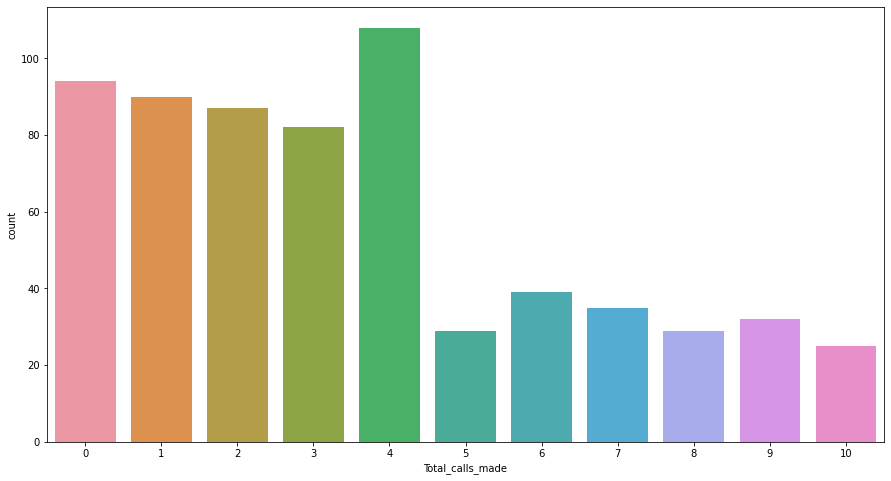

```python
plt.figure(figsize=(15,8))
sns.countplot(mydata['Total_calls_made'])
#plt.xticks(rotation=90)
plt.show()
```

# Checking Outliers And Scaling

```python
##Scale the data
from scipy.stats import zscore
mydata_z = mydata.apply(zscore)
```

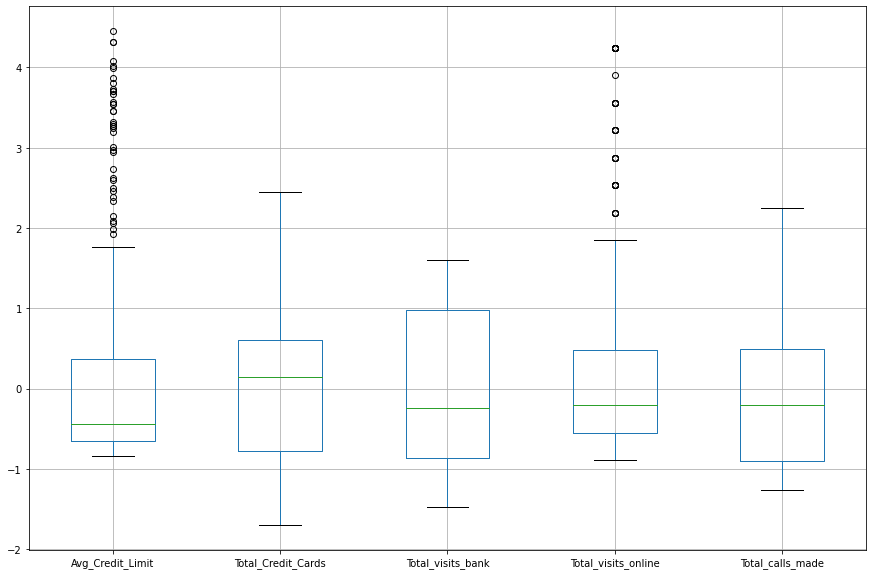

```python
# check for any outliers in data using boxplot
plt.figure(figsize=(15,10))
mydata_z.boxplot()
plt.show()
```

```python
# using logarithmic transform for Avg_Credit_Limit, Total_visits_online to remove outliers
mydata['Avg_Credit_Limit'] = np.log(mydata['Avg_Credit_Limit']+1)
mydata['Total_visits_online'] = np.log(mydata['Total_visits_online']+1)
mydata.head()
```

|  | Avg_Credit_Limit | Total_Credit_Cards | Total_visits_bank | Total_visits_online | Total_calls_made |
| --- | --- | --- | --- | --- | --- |
| 0 | 11.512935 | 2 | 1 | 0.693147 | 0 |
| 1 | 10.819798 | 3 | 0 | 2.397895 | 9 |
| 2 | 10.819798 | 7 | 1 | 1.386294 | 4 |
| 3 | 10.308986 | 5 | 1 | 0.693147 | 4 |
| 5 | 9.903538 | 3 | 0 | 0.693147 | 8 |

```python
#scale the data again
mydata_z = mydata.apply(zscore)
```

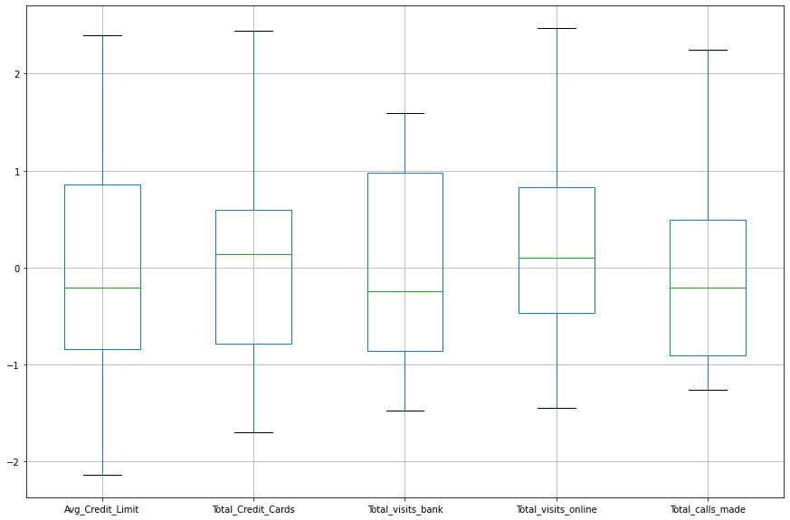

```python
# check for outliers again after logarithmic transform in data using boxplot
plt.figure(figsize=(15,10))
mydata_z.boxplot()
plt.show()
```

# Kmeans Clustering

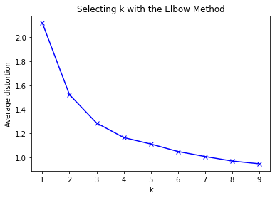

```python
#Finding optimal no. of clusters
from scipy.spatial.distance import cdist
clusters=range(1,10)
meanDistortions=[]

for k in clusters:
    model=KMeans(n_clusters=k)
    model.fit(mydata_z)
    prediction=model.predict(mydata_z)
    meanDistortions.append(sum(np.min(cdist(mydata_z, model.cluster_centers_, 'euclidean'), axis=1)) / mydata_z
                           .shape[0])


plt.plot(clusters, meanDistortions, 'bx-')
plt.xlabel('k')
plt.ylabel('Average distortion')
plt.title('Selecting k with the Elbow Method')
```

### Elbow method indicates 3 clusters as optimal number.

# Kmeans Silhouette Score

```python
from sklearn.metrics import silhouette_score
#Use silhouette score
range_n_clusters = list (range(2,10))
print ("Number of clusters from 2 to 9: \n", range_n_clusters)

for n_clusters in range_n_clusters:
    clusterer = KMeans(n_clusters=n_clusters)
    preds = clusterer.fit_predict(mydata_z)
    centers = clusterer.cluster_centers_

    score = silhouette_score(mydata_z, preds)
    print("For n_clusters = {}, silhouette score is {})".format(n_clusters, score))
```

```
Number of clusters from 2 to 9:
 [2, 3, 4, 5, 6, 7, 8, 9]
For n_clusters = 2, silhouette score is 0.4157581629221606)
For n_clusters = 3, silhouette score is 0.48418338413467216)
For n_clusters = 4, silhouette score is 0.3769351075802019)
For n_clusters = 5, silhouette score is 0.3547968684613657)
For n_clusters = 6, silhouette score is 0.25380759857201735)
For n_clusters = 7, silhouette score is 0.2555935584673917)
For n_clusters = 8, silhouette score is 0.2544867054533321)
For n_clusters = 9, silhouette score is 0.25860271138937263)
```

### Highest Silhouette score indicates 3 clusters as optimal number.

```python
#Set the value of k=3 based on elbow method and silhouette score
kmeansdata = mydata_z.copy()
kmeans = KMeans(n_clusters=3, n_init = 15, random_state=777)
```

```python
kmeans.fit(kmeansdata)
```

```
KMeans(algorithm='auto', copy_x=True, init='k-means++', max_iter=300,
       n_clusters=3, n_init=15, n_jobs=None, precompute_distances='auto',
       random_state=777, tol=0.0001, verbose=0)
```

```python
y = kmeans.fit_predict(kmeansdata)
```

```python
centroids = kmeans.cluster_centers_
```

```python
centroids
```

```
array([[ 0.17507112,  0.37636906,  0.6689594 , -0.63384983, -0.55627954],
       [-0.72420731, -1.04952187, -0.89878615,  0.64333711,  1.13622424],
       [ 1.98221407,  1.9041563 , -1.10638129,  2.0159356 , -0.8864179 ]])
```

```python
#Clculate the centroids for the columns to profile
centroid_df = pd.DataFrame(centroids, columns = list(kmeansdata) )
```

```python
centroid_df.transpose()
```

|  | 0 | 1 | 2 |
| --- | --- | --- | --- |
| Avg_Credit_Limit | 0.175071 | -0.724207 | 1.982214 |
| Total_Credit_Cards | 0.376369 | -1.049522 | 1.904156 |
| Total_visits_bank | 0.668959 | -0.898786 | -1.106381 |
| Total_visits_online | -0.633850 | 0.643337 | 2.015936 |
| Total_calls_made | -0.556280 | 1.136224 | -0.886418 |

## Clusters Comparison - Data Distribution In Groups:

```python
## creating a new dataframe only for labels and converting it into categorical variable
kmeansdata['labels'] = kmeans.labels_
kmeansdata.head(10)
```

|  | Avg_Credit_Limit | Total_Credit_Cards | Total_visits_bank | Total_visits_online | Total_calls_made | labels |
| --- | --- | --- | --- | --- | --- | --- |
| 0 | 1.644978 | -1.241502 | -0.862932 | -0.469013 | -1.258480 | 0 |
| 1 | 0.897140 | -0.781162 | -1.477961 | 1.939831 | 1.893108 | 1 |
| 2 | 0.897140 | 1.060199 | -0.862932 | 0.510418 | 0.142226 | 0 |
| 3 | 0.346016 | 0.139519 | -0.862932 | -0.469013 | 0.142226 | 0 |
| 5 | -0.091429 | -0.781162 | -1.477961 | -0.469013 | 1.542931 | 1 |
| 6 | 1.644978 | 0.139519 | -1.477961 | 2.062780 | -0.558127 | 2 |
| 7 | -0.401796 | -0.781162 | -1.477961 | -0.469013 | -0.908304 | 1 |
| 8 | -1.586963 | -1.241502 | -1.477961 | 0.103917 | -0.558127 | 1 |
| 9 | -2.137958 | -0.320822 | -1.477961 | -0.469013 | 1.192755 | 1 |
| 10 | -0.839223 | -0.320822 | -1.477961 | 1.083349 | 0.492402 | 1 |

```python
kmeansdata['labels'].value_counts()
```

```
0    379
1    223
2     48
Name: labels, dtype: int64
```

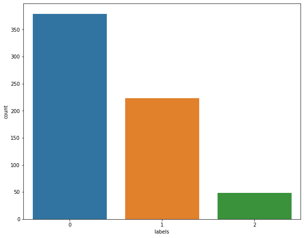

```python
plt.figure(figsize=(10,8))
sns.countplot(kmeansdata['labels'])
#plt.xticks(rotation=90)
plt.show()
```

```python
#To determine if a relationship exists between Avg credit limit and total credit cards
kmeansdata['Avg_Credit_Limit'].corr(kmeansdata['Total_Credit_Cards'])
```

```
0.5859356652030844
```

The correlation coefficient above indicates that the relationship between Avg_Credit_Limit and Total_Credit_Cards can be considered moderate and positive. This means that we can see a clear relationship between Avg_Credit_Limit and Total_Credit_Cards. The fact that the correlation coefficient is positive, indicates that higher average credit card limit means higher number of credit cards.

```python
mydata_z.describe()
```

|  | Avg_Credit_Limit | Total_Credit_Cards | Total_visits_bank | Total_visits_online | Total_calls_made |
| --- | --- | --- | --- | --- | --- |
| count | 6.500000e+02 | 6.500000e+02 | 6.500000e+02 | 6.500000e+02 | 6.500000e+02 |
| mean | 1.455929e-15 | 8.598250e-16 | -5.489626e-16 | 1.318603e-16 | -1.706669e-15 |
| std | 1.000770e+00 | 1.000770e+00 | 1.000770e+00 | 1.000770e+00 | 1.000770e+00 |
| min | -2.137958e+00 | -1.701843e+00 | -1.477961e+00 | -1.448445e+00 | -1.258480e+00 |
| 25% | -8.392230e-01 | -7.811621e-01 | -8.629325e-01 | -4.690135e-01 | -9.083039e-01 |
| 50% | -2.050980e-01 | 1.395185e-01 | -2.479038e-01 | 1.039172e-01 | -2.079510e-01 |
| 75% | 8.530978e-01 | 5.998588e-01 | 9.821534e-01 | 8.257244e-01 | 4.924020e-01 |
| max | 2.392821e+00 | 2.441220e+00 | 1.597182e+00 | 2.469281e+00 | 2.243284e+00 |

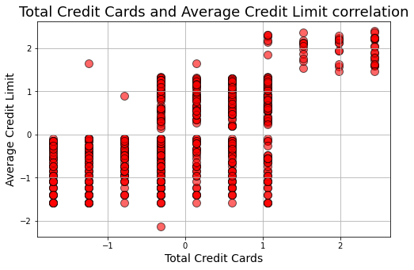

```python
plt.figure(figsize=(8,5))
plt.title("Total Credit Cards and Average Credit Limit correlation",fontsize=18)
plt.xlabel ("Total Credit Cards",fontsize=14)
plt.ylabel ("Average Credit Limit",fontsize=14)
plt.grid(True)
plt.scatter(mydata_z['Total_Credit_Cards'],mydata_z['Avg_Credit_Limit'],color='red',edgecolor='k',alpha=0.6, s=100)
plt.show()
```

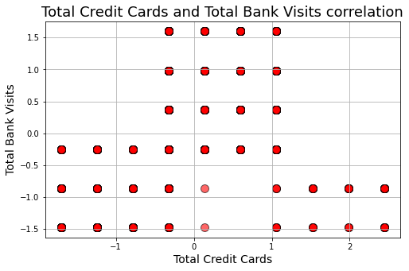

```python
plt.figure(figsize=(8,5))
plt.title("Total Credit Cards and Total Bank Visits correlation",fontsize=18)
plt.xlabel ("Total Credit Cards",fontsize=14)
plt.ylabel ("Total Bank Visits",fontsize=14)
plt.grid(True)
plt.scatter(mydata_z['Total_Credit_Cards'],mydata_z['Total_visits_bank'],color='red',edgecolor='k',alpha=0.6, s=100)
plt.show()
```

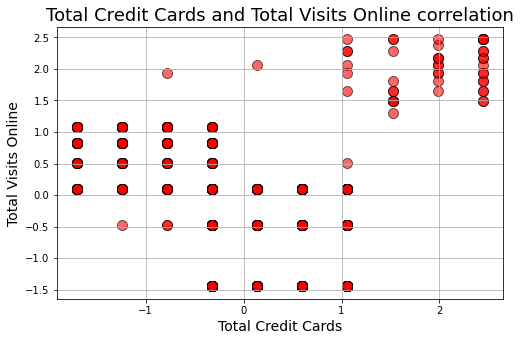

```python
plt.figure(figsize=(8,5))
plt.title("Total Credit Cards and Total Visits Online correlation",fontsize=18)
plt.xlabel ("Total Credit Cards",fontsize=14)
plt.ylabel ("Total Visits Online",fontsize=14)
plt.grid(True)
plt.scatter(mydata_z['Total_Credit_Cards'],mydata_z['Total_visits_online'],color='red',edgecolor='k',alpha=0.6, s=100)
plt.show()
```

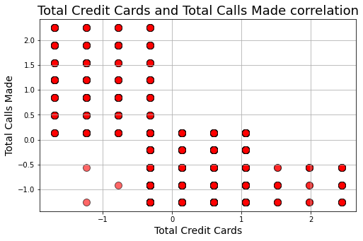

```python
plt.figure(figsize=(8,5))
plt.title("Total Credit Cards and Total Calls Made correlation",fontsize=18)
plt.xlabel ("Total Credit Cards",fontsize=14)
plt.ylabel ("Total Calls Made",fontsize=14)
plt.grid(True)
plt.scatter(mydata_z['Total_Credit_Cards'],mydata_z['Total_calls_made'],color='red',edgecolor='k',alpha=0.6, s=100)
plt.show()
```

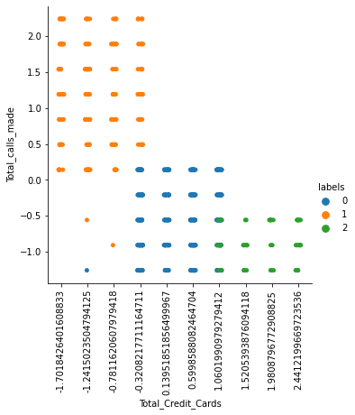

```python
g = sns.catplot(x="Total_Credit_Cards", y="Total_calls_made", hue="labels", data=kmeansdata)
plt.xticks(rotation=90)
plt.show()
```

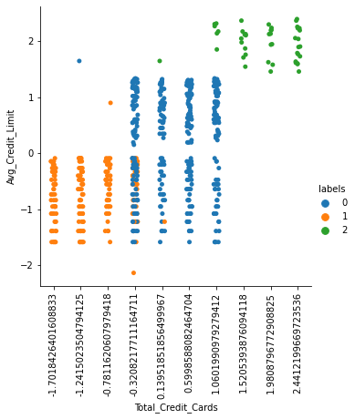

```python
sns.catplot(x="Total_Credit_Cards", y="Avg_Credit_Limit", hue="labels", data=kmeansdata)
plt.xticks(rotation=90)
plt.show()
```

```
array([[<AxesSubplot:title={'center':'Avg_Credit_Limit'}, xlabel='[labels]'>,
        <AxesSubplot:title={'center':'Total_Credit_Cards'}, xlabel='[labels]'>,
        <AxesSubplot:title={'center':'Total_calls_made'}, xlabel='[labels]'>,
        <AxesSubplot:title={'center':'Total_visits_bank'}, xlabel='[labels]'>],
       [<AxesSubplot:title={'center':'Total_visits_online'}, xlabel='[labels]'>,
        <AxesSubplot:>, <AxesSubplot:>, <AxesSubplot:>]], dtype=object)
```

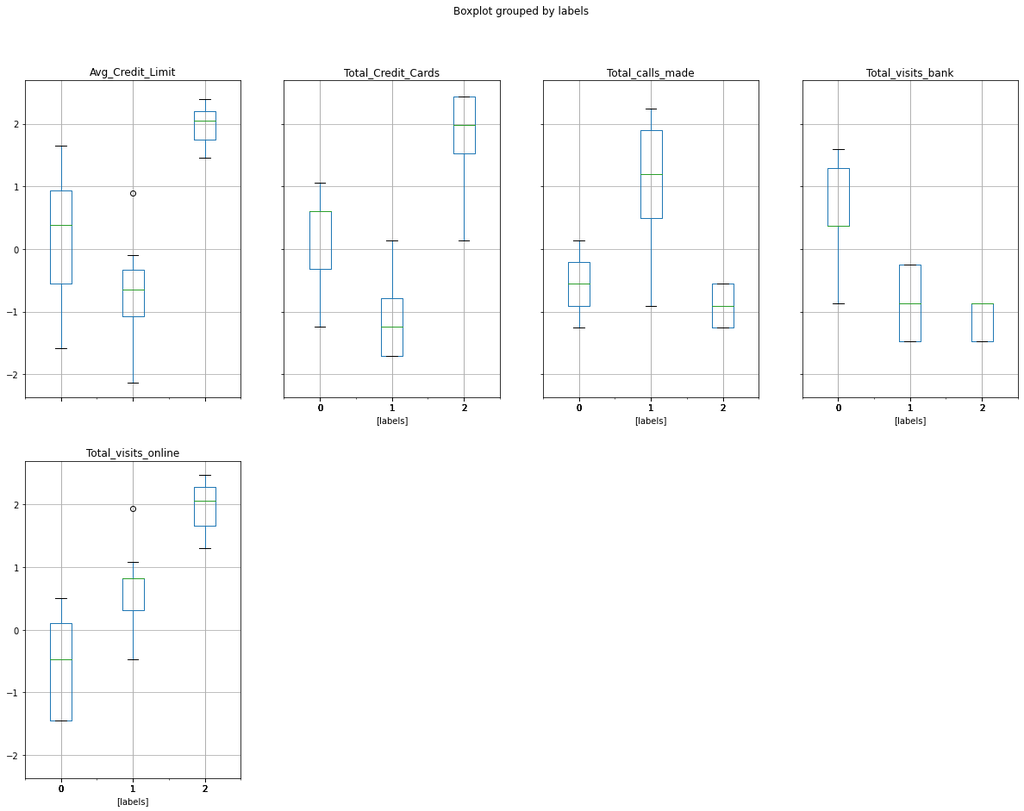

```python
kmeansdata.boxplot(by = 'labels',  layout=(2,4), figsize=(20, 15))
```

```python
mydata_z.head()
```

|  | Avg_Credit_Limit | Total_Credit_Cards | Total_visits_bank | Total_visits_online | Total_calls_made |
| --- | --- | --- | --- | --- | --- |
| 0 | 1.644978 | -1.241502 | -0.862932 | -0.469013 | -1.258480 |
| 1 | 0.897140 | -0.781162 | -1.477961 | 1.939831 | 1.893108 |
| 2 | 0.897140 | 1.060199 | -0.862932 | 0.510418 | 0.142226 |
| 3 | 0.346016 | 0.139519 | -0.862932 | -0.469013 | 0.142226 |
| 5 | -0.091429 | -0.781162 | -1.477961 | -0.469013 | 1.542931 |

# Hierarchical Clustering

```python
from sklearn.cluster import AgglomerativeClustering
```

# Hierarchical Clustering Silhouette Score

```python
#Use silhouette score
range_n_clusters = list (range(2,10))
print ("Number of clusters from 2 to 9: \n", range_n_clusters)

for n_clusters in range_n_clusters:
    clusterer = AgglomerativeClustering(n_clusters=n_clusters, affinity='euclidean',  linkage='average')
    preds = clusterer.fit_predict(mydata_z)
    #centers = clusterer.cluster_centers_

    score = silhouette_score(mydata_z, preds)
    print("For n_clusters = {}, silhouette score is {})".format(n_clusters, score))
```

```
Number of clusters from 2 to 9:
 [2, 3, 4, 5, 6, 7, 8, 9]
For n_clusters = 2, silhouette score is 0.4143272482554229)
For n_clusters = 3, silhouette score is 0.4836864335467579)
For n_clusters = 4, silhouette score is 0.39220284726530824)
For n_clusters = 5, silhouette score is 0.3403293081417722)
For n_clusters = 6, silhouette score is 0.2547321126694173)
For n_clusters = 7, silhouette score is 0.22109140111094422)
For n_clusters = 8, silhouette score is 0.21522707545870023)
For n_clusters = 9, silhouette score is 0.1933021623738328)
```

### Highest Silhouette score indicates 3 clusters as optimal number.

```python
model = AgglomerativeClustering(n_clusters=3, affinity='euclidean',  linkage='average')
```

```python
hcdata = mydata_z.copy()
model.fit(hcdata)
```

```
AgglomerativeClustering(affinity='euclidean', compute_full_tree='auto',
                        connectivity=None, distance_threshold=None,
                        linkage='average', memory=None, n_clusters=3)
```

```python
hcdata['labels'] = model.labels_
hcdata.head(10)
```

|  | Avg_Credit_Limit | Total_Credit_Cards | Total_visits_bank | Total_visits_online | Total_calls_made | labels |
| --- | --- | --- | --- | --- | --- | --- |
| 0 | 1.644978 | -1.241502 | -0.862932 | -0.469013 | -1.258480 | 0 |
| 1 | 0.897140 | -0.781162 | -1.477961 | 1.939831 | 1.893108 | 2 |
| 2 | 0.897140 | 1.060199 | -0.862932 | 0.510418 | 0.142226 | 1 |
| 3 | 0.346016 | 0.139519 | -0.862932 | -0.469013 | 0.142226 | 0 |
| 5 | -0.091429 | -0.781162 | -1.477961 | -0.469013 | 1.542931 | 2 |
| 6 | 1.644978 | 0.139519 | -1.477961 | 2.062780 | -0.558127 | 1 |
| 7 | -0.401796 | -0.781162 | -1.477961 | -0.469013 | -0.908304 | 0 |
| 8 | -1.586963 | -1.241502 | -1.477961 | 0.103917 | -0.558127 | 2 |
| 9 | -2.137958 | -0.320822 | -1.477961 | -0.469013 | 1.192755 | 2 |
| 10 | -0.839223 | -0.320822 | -1.477961 | 1.083349 | 0.492402 | 2 |

```python
hcdata['labels'].value_counts()
```

```
0    379
2    222
1     49
Name: labels, dtype: int64
```

```python
hcdataclust = hcdata.groupby(['labels'])
```

```python
hcdataclust.mean()
```

| labels | Avg_Credit_Limit | Total_Credit_Cards | Total_visits_bank | Total_visits_online | Total_calls_made |
| --- | --- | --- | --- | --- | --- |
| 0 | 0.171644 | 0.371511 | 0.667337 | -0.636434 | -0.559051 |
| 1 | 1.960070 | 1.886933 | -1.101413 | 1.985211 | -0.865425 |
| 2 | -0.725660 | -1.050731 | -0.896177 | 0.648348 | 1.145434 |

```python
from scipy.cluster.hierarchy import cophenet, dendrogram, linkage
```

```python
from scipy.spatial.distance import pdist  #Pairwise distribution between data points
```

```python
# cophenet index is a measure of the correlation between the distance of points in feature space and distance on dendrogram
# closer it is to 1, the better is the clustering

Z = linkage(hcdata, metric='euclidean', method='average')
c, coph_dists = cophenet(Z , pdist(hcdata))

c
```

```
0.8971211379621749
```

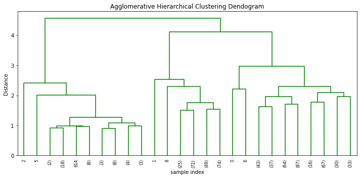

```python
plt.figure(figsize=(10, 5))
plt.title('Agglomerative Hierarchical Clustering Dendogram')
plt.xlabel('sample index')
plt.ylabel('Distance')
dendrogram(Z, leaf_rotation=90.,p=5,color_threshold = 40, leaf_font_size=8.,truncate_mode='level' )
plt.tight_layout()
```

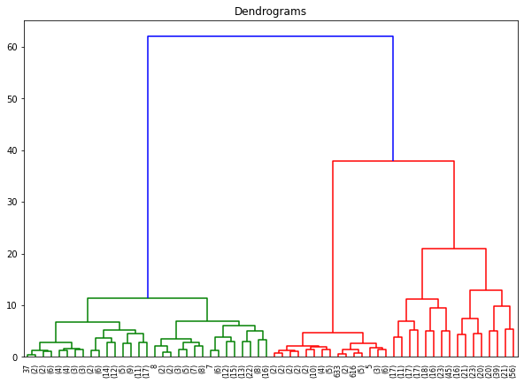

```python
import scipy.cluster.hierarchy as shc
plt.figure(figsize=(10, 7))
plt.title("Dendrograms")
dend = shc.dendrogram(shc.linkage(hcdata, method='ward'),leaf_rotation=90.,p=5,color_threshold = 40, leaf_font_size=8.,truncate_mode='level' )
```

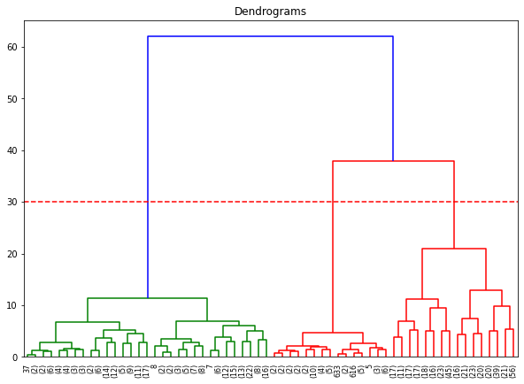

```python
plt.figure(figsize=(10, 7))
plt.title("Dendrograms")
dend = shc.dendrogram(shc.linkage(hcdata, method='ward'),leaf_rotation=90.,p=5,color_threshold = 40, leaf_font_size=8.,truncate_mode='level' )
plt.axhline(y=30, color='r', linestyle='--')
```

```python
from sklearn.cluster import AgglomerativeClustering
cluster = AgglomerativeClustering(n_clusters=3, affinity='euclidean', linkage='ward')
cluster.fit_predict(hcdata)
```

[output not shown]

```python
hcluster = hcdata.copy()
hcluster['labels'] = cluster.labels_
```

```python
hcluster.head()
```

|  | Avg_Credit_Limit | Total_Credit_Cards | Total_visits_bank | Total_visits_online | Total_calls_made | labels |
| --- | --- | --- | --- | --- | --- | --- |
| 0 | 1.644978 | -1.241502 | -0.862932 | -0.469013 | -1.258480 | 0 |
| 1 | 0.897140 | -0.781162 | -1.477961 | 1.939831 | 1.893108 | 1 |
| 2 | 0.897140 | 1.060199 | -0.862932 | 0.510418 | 0.142226 | 0 |
| 3 | 0.346016 | 0.139519 | -0.862932 | -0.469013 | 0.142226 | 0 |
| 5 | -0.091429 | -0.781162 | -1.477961 | -0.469013 | 1.542931 | 1 |

```python
hcluster['labels'].value_counts()
```

```
0    380
1    222
2     48
Name: labels, dtype: int64
```

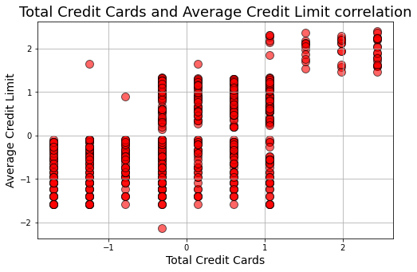

```python
plt.figure(figsize=(8,5))
plt.title("Total Credit Cards and Average Credit Limit correlation",fontsize=18)
plt.xlabel ("Total Credit Cards",fontsize=14)
plt.ylabel ("Average Credit Limit",fontsize=14)
plt.grid(True)
plt.scatter(hcluster['Total_Credit_Cards'],hcluster['Avg_Credit_Limit'],color='red',edgecolor='k',alpha=0.6, s=100)
plt.show()
```

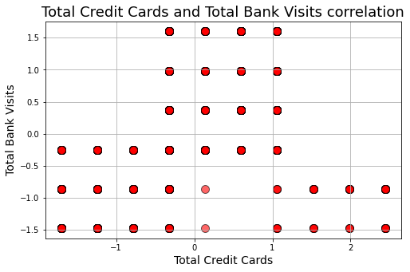

```python
plt.figure(figsize=(8,5))
plt.title("Total Credit Cards and Total Bank Visits correlation",fontsize=18)
plt.xlabel ("Total Credit Cards",fontsize=14)
plt.ylabel ("Total Bank Visits",fontsize=14)
plt.grid(True)
plt.scatter(hcluster['Total_Credit_Cards'],hcluster['Total_visits_bank'],color='red',edgecolor='k',alpha=0.6, s=100)
plt.show()
```

```
array([[<AxesSubplot:title={'center':'Avg_Credit_Limit'}, xlabel='[labels]'>,
        <AxesSubplot:title={'center':'Total_Credit_Cards'}, xlabel='[labels]'>,
        <AxesSubplot:title={'center':'Total_calls_made'}, xlabel='[labels]'>,
        <AxesSubplot:title={'center':'Total_visits_bank'}, xlabel='[labels]'>],
       [<AxesSubplot:title={'center':'Total_visits_online'}, xlabel='[labels]'>,
        <AxesSubplot:>, <AxesSubplot:>, <AxesSubplot:>]], dtype=object)
```

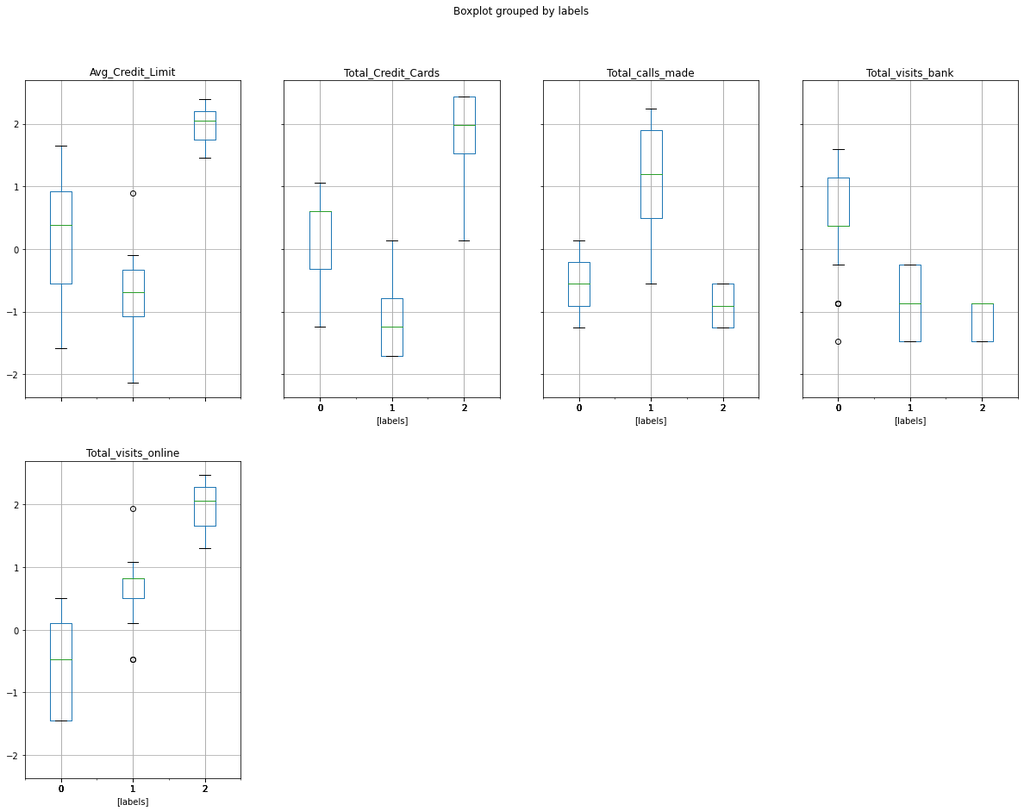

```python
hcluster.boxplot(by = 'labels',  layout=(2,4), figsize=(20, 15))
```

## Analysis Of Cluster Groups Formed:

#### Group 0: Medium Income Customers

```
- Has the highest total number of bank visits
- Has the lowest total number of online visits
- Median number of total credit cards and median average credit card limit
```

##### Group 0 Inference: Traditional low/medium income customer with traditional shopping habits, using less online services

#### Group 1: Lowest Income Customers

```
- Has the lowest total number of credit cards with lowest average credit limit
- Has the highest total number of calls made
```

##### Group 1 Inference: Lowest income customers with lower average credit limit and less number of credit cards

#### Group 2: Highest Income Customers

```
- Has the highest Average Credit Limit
- Has the highest Total Number Of Credit Cards
- Has the lowest Total Number Of Calls Made By The Customer
- Has the lowest visits to the bank and highest visits online
```

##### Group 2 Inference: High income customers using online services the most. Most educated, sophisticated customers who may probably does not need any help with services.

# Recommendation to Bank:

### Group 0 has customers who can be motivated with appropriate incentives to use more online services, shopping etc. so they need less bank visits and do more online. This can help bank manage the required staff in the offices and manage/save costs.

### Group 1 needs to be studied for frequent calls made by the customers and design new strategies accordingly. This group seems to be the low income customers. Bank may not be earning a lot from these customers, yet these customers seem to be needing most help.

### Group 2 has the least opportunities as that group of customers seems to be mostly self sufficient. However more online services can be targated to this customer group.